# BAM-alignment genome coverage and missing data in the ZEAL population

- Show All Code
- Hide All Code
- View Source

Missing-data modelling in ZEAL, part 2 of 3 — the exponential-with-floor model

Author

Fausto Rodríguez-Zapata

Published

July 16, 2026

**Purpose.** Extend the Poisson baseline from `missing-data-coverage-theory.qmd` into a model that actually fits the ZEAL data. We analyze **BAM alignments directly** — before any genotype calling or VCF filtering — and show that per-sample missingness follows an *exponential-with-floor* law rather than the pure Poisson expectation.

**NoteWhere this sits in the series**

1. `missing-data-coverage-theory.qmd` — Poisson coverage theory (the baseline).
2. **This note** — the exponential-with-floor model, fit to ZEAL BAM alignments.
3. `missing-data-model-comparison.qmd` — the floor model applied to three ZEAL datasets.

```r
suppressMessages({
  library(here)
  library(readr)
  library(dplyr)
  library(tidyr)
  library(ggplot2)
  library(ggpubr)
  library(cowplot)
  library(minpack.lm) # nlsLM: robust Levenberg-Marquardt nonlinear least squares
  library(viridis)
})
```

# 1 Introduction

This analysis examines genome coverage and the distribution of missing read data in the **ZEAL** maize–teosinte population without calling genotypes or relying on VCF files. Instead, we analyze the **BAM alignments** directly, prior to any genotype calling. We used GATK’s `CollectAllelicCounts` on the BAM files, restricting read counting to sites corresponding to ~27 million known teosinte variants (the `wideseq_ref` panel). For each site and sample the tool counted the number of reads supporting each allele, and these counts were aggregated into 1 Mb bins for the initial file in the workflow.

By aggregating the per-bin read counts across the genome, we estimate coverage ($\lambda$) and compare the **observed fraction of missing genotype calls** against the **expected missing fraction** under the Poisson coverage model.

## 1.1 Theoretical background

Modeling missingness in sequencing data involves both stochastic sampling effects and systematic biases. The foundational concept is the Poisson coverage model, where the probability of observing zero reads at a site decreases exponentially with increasing coverage — this reflects the stochastic nature of read sampling.

Additionally, certain genomic regions inherently exhibit higher missingness due to low-complexity/repetitive sequences or structural variation. This leads to an irreducible baseline missingness that persists even at high coverage with short reads. These two facts are the basis for the **exponential-with-floor** model: a parsimonious and mechanistically interpretable summary of missingness across samples.

## 1.2 Models of missingness

### 1.2.1 Poisson model

If reads are randomly and independently distributed across the genome, the probability of missing a site is

$$P_{\text{missing}} = e^{-\lambda}$$

where $\lambda$ is the mean coverage (average reads per variant site) and $P_{\text{missing}}$ is the probability of no reads covering a site. This serves as a baseline to evaluate whether missingness arises purely from random sequencing variation or whether additional biases (e.g. mapping issues) contribute.

### 1.2.2 Exponential-with-floor model

We model per-sample missingness as

$$P_{\text{missing}} = \pi + (1 - \pi)\, e^{-k \lambda}$$

where:

- $\lambda$ is the mean coverage.
- $\pi$ (**floor parameter**) is the fraction of sites that remain uncalled even at high coverage with short reads. This baseline missingness likely corresponds to repetitive DNA, structural variants, or highly polymorphic regions where short reads fail to map or are discarded by mapping filters. For example, `picard CollectWgsMetrics` reports a `PCT_EXC_TOTAL` statistic that can be interpreted as a floor parameter — for the *alux* project, at nominal coverage $3.2\times$ I obtained a mean $\text{PCT\_EXC\_TOTAL} = 0.45 \sim \pi$.
- $k$ (**decay rate**) is how fast missingness decays with increasing coverage relative to the Poisson model. I interpret the product $k\lambda$ as an *effective coverage* (perhaps the coverage of the informative variants).

# 2 Data loading and processing

The input is a small per-sample summary of the aggregated 1 Mb bin allele-count table (`all_samples_bin_genotypes.tsv`), reduced to per-sample variant/depth counts by `scripts/make_missing_data_summaries.R` (run once on-mount; see `DATA.md`). The notebook reads only this summary, so it renders with no mount attached. The genotype **calls** in the source file are irrelevant here — we use only depth and variant counts.

```r
summary_file <- here("data/missing_data/wideseq_per_sample.tsv")
stopifnot(file.exists(summary_file))
per_sample <- read_tsv(summary_file, show_col_types = FALSE) %>%
  mutate(missing_poisson = exp(-lambda))
```

```r
# Overall (pooled) population statistics
overall_stats <- per_sample %>%
  summarize(
    VARIANT_COUNT             = sum(VARIANT_COUNT, na.rm = TRUE),
    INFORMATIVE_VARIANT_COUNT = sum(INFORMATIVE_VARIANT_COUNT, na.rm = TRUE),
    DEPTH_SUM                 = sum(DEPTH_SUM, na.rm = TRUE)
  ) %>%
  mutate(
    lambda          = DEPTH_SUM / VARIANT_COUNT,
    missing_obs     = 1 - INFORMATIVE_VARIANT_COUNT / VARIANT_COUNT,
    missing_poisson = exp(-lambda)
  )

overall_stats
```

```
# A tibble: 1 × 6
  VARIANT_COUNT INFORMATIVE_VARIANT_COUNT   DEPTH_SUM lambda missing_obs
          <dbl>                     <dbl>       <dbl>  <dbl>       <dbl>
1   39583816218               13065064063 23361989704  0.590       0.670
# ℹ 1 more variable: missing_poisson <dbl>
```

The population-level mean coverage is $\lambda \approx 0.59$, with an observed missingness of $\approx 0.67$ — already above the Poisson expectation of $\approx 0.554$.

# 3 Coverage distribution analysis

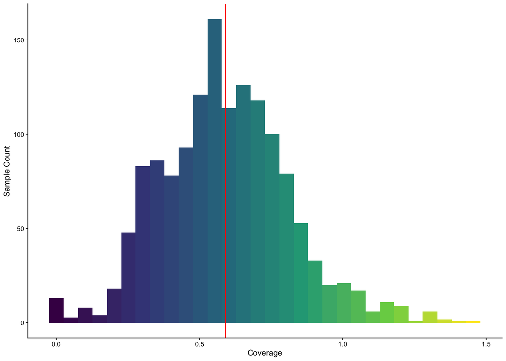

```r
lambda_bar <- overall_stats$lambda
p_hist <- per_sample %>%
  ggplot(aes(x = lambda)) +
  xlab("Coverage") +
  ylab("Sample Count") +
  geom_histogram(aes(fill = after_stat(x))) +
  geom_vline(xintercept = lambda_bar, color = "red") +
  scale_fill_viridis_c() +
  ggpubr::theme_classic2(base_size = 8) +
  theme(legend.position = "none")

print(p_hist)
```

The coverage distribution has a mean of ~0.59 with substantial spread across samples.

# 4 Model fitting

## 4.1 Simple exponential model

A first pass: regress log-missingness on coverage to get a rough decay rate.

```r
fit_linear <- lm(log(missing_obs) ~ lambda, data = per_sample)
per_sample$missing_exp_k <- exp(predict(fit_linear))

k_est <- -coef(fit_linear)[2]
cat("Estimated k:", round(k_est, 3), "\n")
```

```
Estimated k: 0.581
```

```r
cat(
  "Effective coverage (k*lambda) range:",
  paste0(round(k_est * range(per_sample$lambda), 3), collapse = " - "), "\n"
)
```

```
Effective coverage (k*lambda) range: 0 - 0.846
```

## 4.2 Exponential-with-floor model

Now the full model, fit by robust nonlinear least squares (`nlsLM`), using the linear-model estimates as starting values.

```r
# Restrict to samples with well-defined missingness in (0, 1)
dat <- per_sample %>%
  filter(
    is.finite(lambda), is.finite(missing_obs),
    missing_obs > 0, missing_obs < 1
  )

# Initial estimate of the floor from a linear fit of observed vs Poisson
fit_missing <- lm(missing_obs ~ missing_poisson, data = per_sample)
pi_est <- coef(fit_missing)[1]

fit_exp_floor <- nlsLM(
  missing_obs ~ pi + (1 - pi) * exp(-k * lambda),
  data  = dat,
  start = list(pi = pi_est, k = k_est),
  lower = c(0, 0),
  upper = c(1, 10)
)

model_params <- coef(fit_exp_floor)
pi <- model_params[1]
k <- model_params[2]

cat("Floor parameter (pi):", round(pi, 3), "\n")
```

```
Floor parameter (pi): 0.346
```

```r
cat("Decay rate (k):", round(k, 3), "\n")
```

```
Decay rate (k): 1.256
```

```r
per_sample$missing_exp_floor <- predict(fit_exp_floor, newdata = per_sample)
overall_stats$missing_exp_floor <- predict(
  fit_exp_floor,
  newdata = data.frame(lambda = overall_stats$lambda)
)
```

# 5 Model comparison

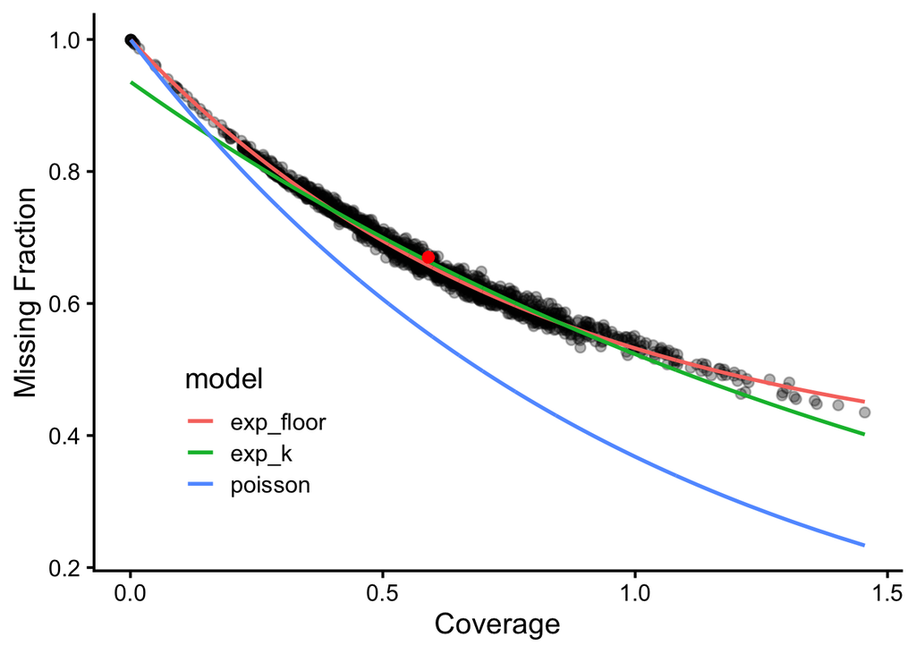

```r
decay_plot <- per_sample %>%
  select(-missing_obs) %>%
  ungroup() %>%
  tidyr::pivot_longer(
    cols = starts_with("missing_"),
    names_to = "model", values_to = "pred",
    names_prefix = "missing_"
  ) %>%
  ggplot(aes(x = lambda, y = pred, col = model, group = model)) +
  geom_point(
    data = per_sample, aes(x = lambda, y = missing_obs),
    inherit.aes = FALSE, alpha = 0.3
  ) +
  geom_line(linewidth = 1) +
  xlab("Coverage") +
  ylab("Missing Fraction") +
  geom_point(x = lambda_bar, y = overall_stats$missing_obs, color = "red") +
  ggpubr::theme_classic2(base_size = 16) +
  theme(legend.position = c(0.2, 0.25), legend.box = "horizontal")

print(decay_plot)
```

# 6 Model validation

Common scales for the validation scatter plots.

```r
xy_limits <- c(0.2, 1.0)
legend_breaks <- c(0, 0.5, 1.0, 1.5)
legend_labels <- as.character(legend_breaks)
```

## 6.1 Poisson model assessment

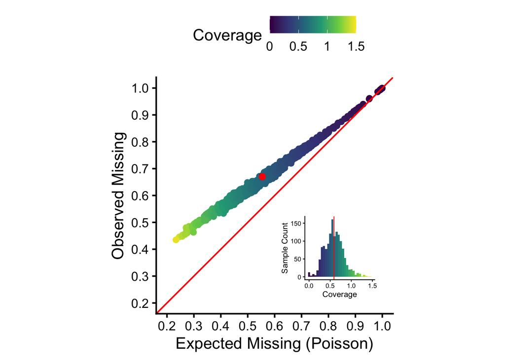

```r
p_scatter_poisson <- per_sample %>%
  ggplot(aes(x = missing_poisson, y = missing_obs, col = lambda)) +
  geom_point() +
  geom_abline(slope = 1, intercept = 0, color = "red") +
  scale_color_viridis_c(
    breaks = legend_breaks, labels = legend_labels,
    limits = c(0, 1.5)
  ) +
  guides(col = guide_colorbar(title = "Coverage")) +
  geom_point(
    x = overall_stats$missing_poisson, y = overall_stats$missing_obs,
    color = "red"
  ) +
  scale_x_continuous(limits = xy_limits, breaks = (2:10) / 10) +
  scale_y_continuous(limits = xy_limits, breaks = (2:10) / 10) +
  coord_fixed(ratio = 1) +
  xlab("Expected Missing (Poisson)") +
  ylab("Observed Missing") +
  ggpubr::theme_classic2(base_size = 16) +
  theme(legend.position = "top")

inlay_grob <- cowplot::as_grob(p_hist)

final_plot_poisson <- cowplot::ggdraw() +
  cowplot::draw_plot(p_scatter_poisson) +
  cowplot::draw_plot(inlay_grob, x = 0.55, y = 0.16, width = 0.2, height = 0.25)

print(final_plot_poisson)
```

The Poisson model systematically **underpredicts** missingness: observed points sit above the 1:1 line.

## 6.2 Exponential-with-floor model assessment

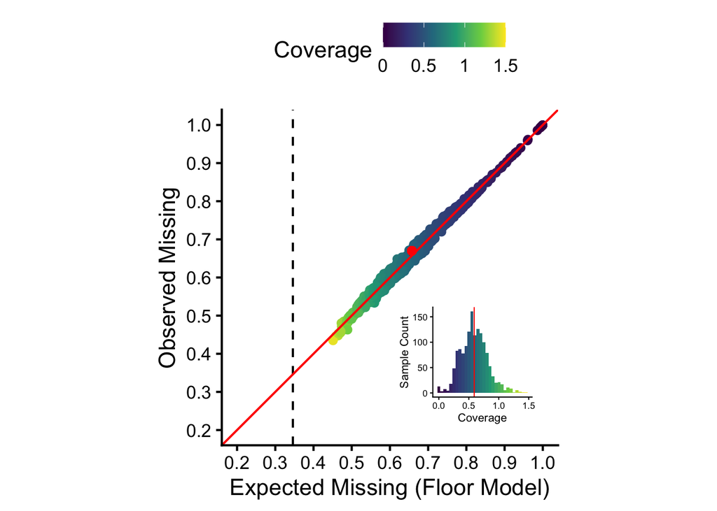

```r
p_scatter_floor <- per_sample %>%
  ggplot(aes(x = missing_exp_floor, y = missing_obs, col = lambda)) +
  geom_point() +
  geom_vline(xintercept = pi, linetype = "dashed") +
  geom_abline(slope = 1, intercept = 0, color = "red") +
  scale_color_viridis_c(
    breaks = legend_breaks, labels = legend_labels,
    limits = c(0, 1.5)
  ) +
  guides(col = guide_colorbar(title = "Coverage")) +
  geom_point(
    x = overall_stats$missing_exp_floor,
    y = overall_stats$missing_obs, color = "red"
  ) +
  scale_x_continuous(limits = xy_limits, breaks = (2:10) / 10) +
  scale_y_continuous(limits = xy_limits, breaks = (2:10) / 10) +
  coord_fixed(ratio = 1) +
  xlab("Expected Missing (Floor Model)") +
  ylab("Observed Missing") +
  ggpubr::theme_classic2(base_size = 16) +
  theme(legend.position = "top")

final_plot_floor <- cowplot::ggdraw() +
  cowplot::draw_plot(p_scatter_floor) +
  cowplot::draw_plot(inlay_grob, x = 0.55, y = 0.16, width = 0.2, height = 0.25)

print(final_plot_floor)
```

The floor model places points on the 1:1 line; the dashed line marks the floor $\pi$, the minimum missingness attainable no matter how high the coverage.

# 7 Results summary

```r
cat("Population-level Statistics:\n")
```

```
Population-level Statistics:
```

```r
cat("Mean coverage (lambda):", round(overall_stats$lambda, 3), "\n")
```

```
Mean coverage (lambda): 0.59
```

```r
cat("Observed missingness:", round(overall_stats$missing_obs, 3), "\n")
```

```
Observed missingness: 0.67
```

```r
cat("Poisson expectation:", round(overall_stats$missing_poisson, 3), "\n")
```

```
Poisson expectation: 0.554
```

```r
cat("Floor model expectation:", round(overall_stats$missing_exp_floor, 3), "\n\n")
```

```
Floor model expectation: 0.658
```

```r
cat("Model Parameters:\n")
```

```
Model Parameters:
```

```r
cat("Floor parameter (pi):", round(pi, 3), "\n")
```

```
Floor parameter (pi): 0.346
```

```r
cat("Decay rate (k):", round(k, 3), "\n")
```

```
Decay rate (k): 1.256
```

Part 3 (`missing-data-model-comparison.qmd`) evaluates how stable $\pi$ and $k$ are when the same model is fit to three different ZEAL data products.

# 8 References

Li, H., Ruan, J., & Durbin, R. (2008). Mapping short DNA sequencing reads and calling variants using mapping quality scores. *Bioinformatics*, 24(3), 223–230.

Nielsen, R., Paul, J. S., Albrechtsen, A., & Song, Y. S. (2011). Genotype and SNP calling from next-generation sequencing data. *Nature Reviews Genetics*, 12(6), 443–451.